# Modular dada2 pipeline

Sudarshan

Mon Mar 22 14:33:40 2021

# Introduction

## Steps

Converting the dada2 big data workflow into a modular pipeline for analysing multiple sequencing libraries.

Divided into

- Preprocessing
- Infer Sequence Variants and remove chimera
- Taxonomic assignments

## Codes

This is accomplished by set of three functions.

- Preprocessing
  - 01_preprocessing.R
- Infer Sequence Variants and remove chimera
  - 02_inferSequenceVariantsBD.R
- Taxonomic assignments
  - 03_taxonomyAssignments.R

# Analysis

Test data are located in `raw_data` folder.

## Required libraries

```r
library(dada2)
library(ggplot2)
library(tidyverse)

#library(readr)
```

## Preprocessing

```r
# source the function
source("R/01_preprocessing.R")

filter_tab <- filterTrimReads(path_to_all_files = "raw_data/library_1/",
                              plot_qc_profile = TRUE,
                              fwd_file_pattern = "R1_001.fastq",
                              rev_file_pattern= "R2_001.fastq",
                              flag.library.size = 1000,
                              prefix = "library_1",
                              truncLen=c(200,150),
                              maxEE=c(2,2),
                              truncQ=2,
                              maxN=0,
                              rm.phix=TRUE,
                              compress=TRUE,
                              verbose=TRUE,
                              multithread=TRUE)
```

```
## Subdirectories created here:
## raw_data/library_1//REV
## raw_data/library_1//FWD
```

```
## QualityProfile stored here:
## raw_data/library_1/plotQualityProfile/library_1_FWD_QC_aggregated_plot.pdf
## raw_data/library_1/plotQualityProfile/library_1_REV_QC_aggregated_plot.pdf
```

```
## Filtered fastq (fastq.gz) files stored here:
## raw_data/library_1//FWD/filtered
## raw_data/library_1//REV/filtered
```

```
## Filter trim summary stored here: raw_data/library_1/trimSummary/library_1_trimSummary.tsv
```

Check how many reads were retained.

```r
DT::datatable(filter_tab)
```

|  | input_file | reads.in | reads.out | reads.lost.number | reads.lost.percent | is.low.reads.in | is.low.reads.out | run.number |
| --- | --- | --- | --- | --- | --- | --- | --- | --- |
| 1 | 052_007_S7_R1_001.fastq.gz | 16555 | 16033 | 522 | 3.15 | NO | NO | library_1 |
| 2 | 052_010_S10_R1_001.fastq.gz | 16150 | 15529 | 621 | 3.85 | NO | NO | library_1 |
| 3 | 052_013_S13_R1_001.fastq.gz | 20832 | 20260 | 572 | 2.75 | NO | NO | library_1 |
| 4 | 052_017_S17_R1_001.fastq.gz | 14733 | 14348 | 385 | 2.61 | NO | NO | library_1 |

## Infer Sequence Variants

Once raw reads are filtered and trimmed, run the `02_inferSequenceVariantsBD.R`  
This has a function called *inferSequenceVariantsBD* which infers sequence variants.

```r
source("R/02_inferSequenceVariantsBD.R")

isv <- inferSequenceVariantsBD(path_to_output_name="MainOut/",
                               path_fwd_files_filterd = "raw_data/library_1/FWD/filtered",
                               path_rev_files_filterd = "raw_data/library_1/REV/filtered",
                               seed_number = 100,
                               plot_errors = TRUE,
                               multithread=TRUE,
                               nbases_for_errors = 1e9,
                               randomize_for_errors = TRUE,
                               prefix = "library_1")
```

```
## Number of files
## Forward: 4
## Reverse: 4
```

```
## 13234000 total bases in 66170 reads from 4 samples will be used for learning the error rates.
## 9925500 total bases in 66170 reads from 4 samples will be used for learning the error rates.
```

```
## Estimated error rates plots stored here:
## MainOut/library_1_FWD_Errors_plot.pdf
## MainOut/library_1_REV_Errors_plot.pdf
```

```
## Processing: 052_007
## Sample 1 - 16033 reads in 2664 unique sequences.
## Sample 1 - 16033 reads in 2495 unique sequences.
## Processing: 052_010
## Sample 1 - 15529 reads in 3179 unique sequences.
## Sample 1 - 15529 reads in 2928 unique sequences.
## Processing: 052_013
## Sample 1 - 20260 reads in 3399 unique sequences.
## Sample 1 - 20260 reads in 2798 unique sequences.
## Processing: 052_017
## Sample 1 - 14348 reads in 2577 unique sequences.
## Sample 1 - 14348 reads in 2129 unique sequences.
```

```
## Dada2 seqtab stored here: MainOut/library_1_seqtab.rds
```

```
## Bimera removed seqtab stored here: MainOut/library_1_seqtab_nochimera.rds
```

```
## Dada2 summary stored here: MainOut/library_1_ASVSummary.tsv
```

Check how the data was processed.

```r
DT::datatable(isv$isvSummaryTable)
```

|  | row.names | dadaF | dadaR | merged | no.chimera | run.number |
| --- | --- | --- | --- | --- | --- | --- |
| 1 | 052_007 | 15873 | 15924 | 14941 | 11554 | library_1 |
| 2 | 052_010 | 15332 | 15303 | 14135 | 12090 | library_1 |
| 3 | 052_013 | 19918 | 19979 | 18450 | 14629 | library_1 |
| 4 | 052_017 | 14148 | 14189 | 13138 | 9535 | library_1 |

Access the seqtab

```r
myseqtab <- isv$seqTab
```

## Taxonomic assignments

After running the `01_preprocessing.R` and `02_inferSequenceVariantsBD.R` per library, there will be several chimera removed `seqtabs` that need to be merged and used for taxonomic classification.

```r
# example merge
# read your seqtabs
# seqtb1 <- readRDS("MainOut/Library_1_seqtab_nochimera.rds")
# seqtb2 <- readRDS("MainOut/Library_2_seqtab_nochimera.rds")
# seqtb3 <- readRDS("MainOut/Library_3_seqtab_nochimera.rds")

# input_tables <- list(seqtb1, seqtb2, seqtb3)
# mergetab <- mergeSequenceTables(tables=input_tables,
#                                tryRC = TRUE) # check for reverse complemet when merging
```

Once the merged seq tab is ready, run the `03_taxonomyAssignments.R`  
This has a function called *ClassifyASV*

```r
source("R/03_taxonomyAssignments.R")
# This has a function called 'ClassifyASV'

# here i run only one library, so will use that as example
seqtb_nochim <- readRDS("MainOut/library_1_seqtab_nochimera.rds")

ClassifyASV(input_seqtab = seqtb_nochim,
            path_to_output_name = "MainOut/",
            training_set = "silvaDBv138.1/silva_nr99_v138.1_train_set.fa.gz",
            training_set_species = "silvaDBv138.1/silva_species_assignment_v138.1.fa.gz",
            minBoot=80,
            multithread = 4,
            tryRC = TRUE,
            verbose = TRUE,
            set.seed=356)
```

```
## Finished processing reference fasta.81 out of 163 were assigned to the species level.
## Of which 72 had genera consistent with the input table.
```

The taxonomy files are now located in the location specified by the user in the `path_to_output_name`.

### Putting it all together

Create a phyloseq object.

```r
library(phyloseq)
# Non chimeric setab used as input for 'ClassifyASV'
st.all <- readRDS("MainOut/library_1_seqtab_nochimera.rds")

# Species level taxonomy from 'ClassifyASV'
taxa_sp <- readRDS("MainOut/taxa_addSpecies.rds") # CHANGE ME

# Add metadata making dummy here for example

metadata <- data.frame(sample_id = rownames(st.all))
rownames(metadata) <-  metadata$sample_id

ps <- phyloseq(otu_table(st.all, taxa_are_rows=FALSE),
               tax_table(taxa_sp),
               sample_data(metadata))
```

# Testing biomeUtils functionality

Check percent of classification of ASVs at different taxomic levels.

```r
source("R/04_biomUtils_test_codes.R")
# Check how many are classified
summarizeTaxonomicAssignments(ps)
```

```
## In Species column- 15 are ambigous assignments
```

```
## # A tibble: 7 x 4
##   Ranks   TaxonomyAssigned Total PrecentAssigned
##   <chr>              <int> <int>           <dbl>
## 1 Kingdom              163   163           100
## 2 Phylum               163   163           100
## 3 Class                161   163            98.8
## 4 Order                161   163            98.8
## 5 Family               158   163            96.9
## 6 Genus                138   163            84.7
## 7 Species               72   163            44.2
```

### Tree libs

Building a phylogenetic tree

```r
library(phangorn)
library(Biostrings)
library(DECIPHER)
library(microbiomeutilities)
library(ggpubr)
```

### Add refSeq

```r
# from microbiomeutilities use add_refseq function
ps <- microbiomeutilities::add_refseq(ps)
```

### Build Tree

```r
seqs <- ps@refseq

sp.tree <- buildSeqTree(seqs)
```

[output not shown]

```
## negative edges length changed to 0!
```

```r
sp.tree$tree
```

```
##
## Phylogenetic tree with 163 tips and 161 internal nodes.
##
## Tip labels:
##  ASV1, ASV2, ASV3, ASV4, ASV5, ASV6, ...
##
## Unrooted; includes branch lengths.
```

```r
ps@phy_tree <- sp.tree$tree

# check is phy_tree is added
ps
```

```
## phyloseq-class experiment-level object
## otu_table()   OTU Table:         [ 163 taxa and 4 samples ]
## sample_data() Sample Data:       [ 4 samples by 1 sample variables ]
## tax_table()   Taxonomy Table:    [ 163 taxa by 7 taxonomic ranks ]
## phy_tree()    Phylogenetic Tree: [ 163 tips and 161 internal nodes ]
## refseq()      DNAStringSet:      [ 163 reference sequences ]
```

## Calculate QC metrics

```r
myqc <- calculateQC(ps)
```

Get sample and taxa qc

```r
sampleQC <- myqc$SampleQC

taxaQC <- myqc$TaxaQC
```

# Testing BiomeViz functionality

## Library size vs No. of ASVs

Check for relation between reads/sample and number of taxa identified.

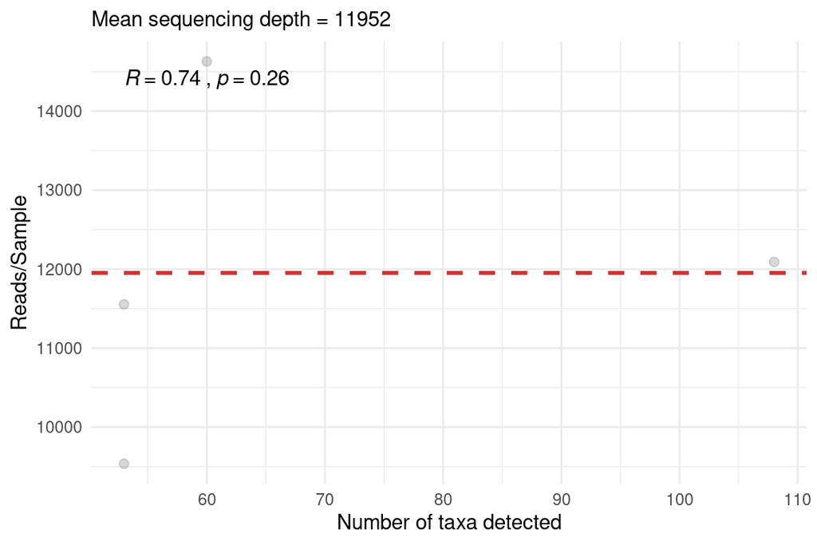

```r
sample_mean_reads = round(mean(sample_sums(ps), na.rm=T), 0)

p1 <- ggplot(sampleQC, aes(sample_total_taxa,sample_total_reads)) +
  geom_hline(yintercept = sample_mean_reads,
             lty=2, size=1, color= "brown3") +
  geom_point(alpha=0.25, size=2, color="grey40") +
  labs(subtitle = paste0("Mean sequencing depth = ", sample_mean_reads)) +
  ylab("Reads/Sample") +
  xlab("Number of taxa detected")  +
  theme_minimal() +
  ggpubr::stat_cor(method = "spearman")
p1
```

## Pevalence vs Taxa counts

Check for relation between Pevalence and total counts of taxa.

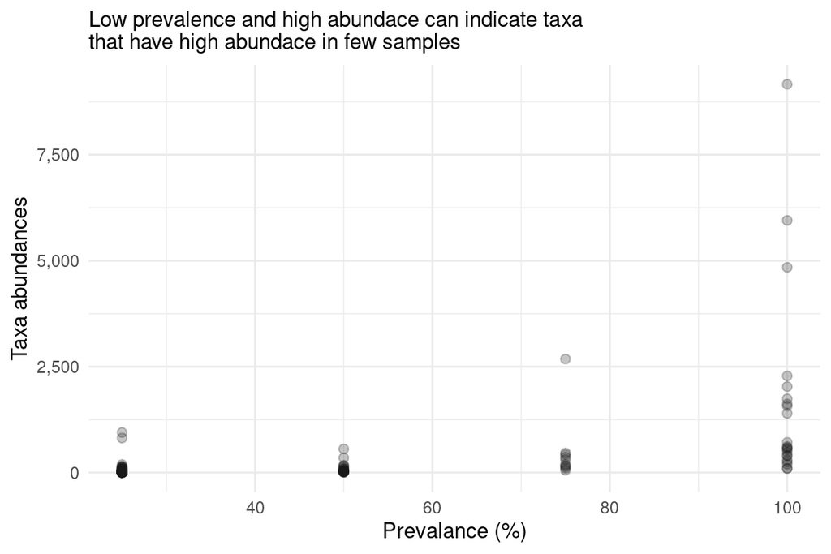

```r
p2 <- ggplot(taxaQC, aes(taxa_prevalence,taxa_counts)) +
  geom_point(alpha=0.25, size=2, color="grey10") +
  #geom_smooth(size = 1) +
  theme_minimal() +
  scale_y_continuous(labels = scales::comma) +
  xlab("Prevalance (%)") +
  ylab("Taxa abundances") +
  labs(subtitle = "Low prevalence and high abundace can indicate taxa \nthat have high abundace in few samples")
p2
```

## Coefficient of variation vs Pevalence

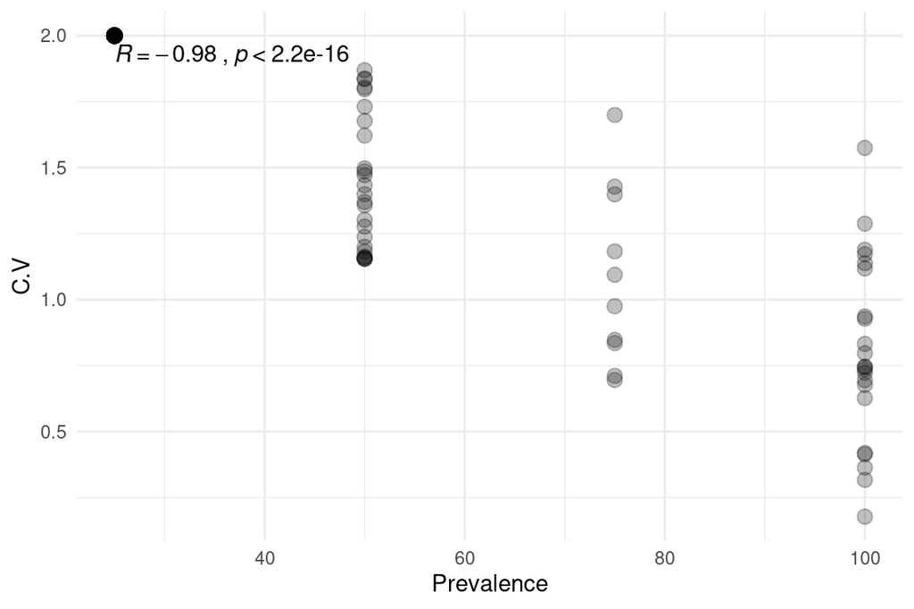

```r
p6 <- ggplot(taxaQC, aes(taxa_prevalence, taxa_cv)) +
  geom_point(alpha = 0.25, size=3) +
  theme_minimal() +
  ylab("C.V") +
  xlab("Prevalence") +
  ggpubr::stat_cor(method = "spearman")
p6
```

Higher prevalence lower C.V. Makes sense as mostly rare/low-abundant taxa contribute to much of the noise in data.

### Trend in taxonomic assignment

Check if the more abundance-prevalent taxa have better taxonomic assignments. This is a pre-check, not corrected for differences in sequencing depth. However, it gives an idea if there is a trend for abundance-prevalent taxa to have better taxonomic assignments.

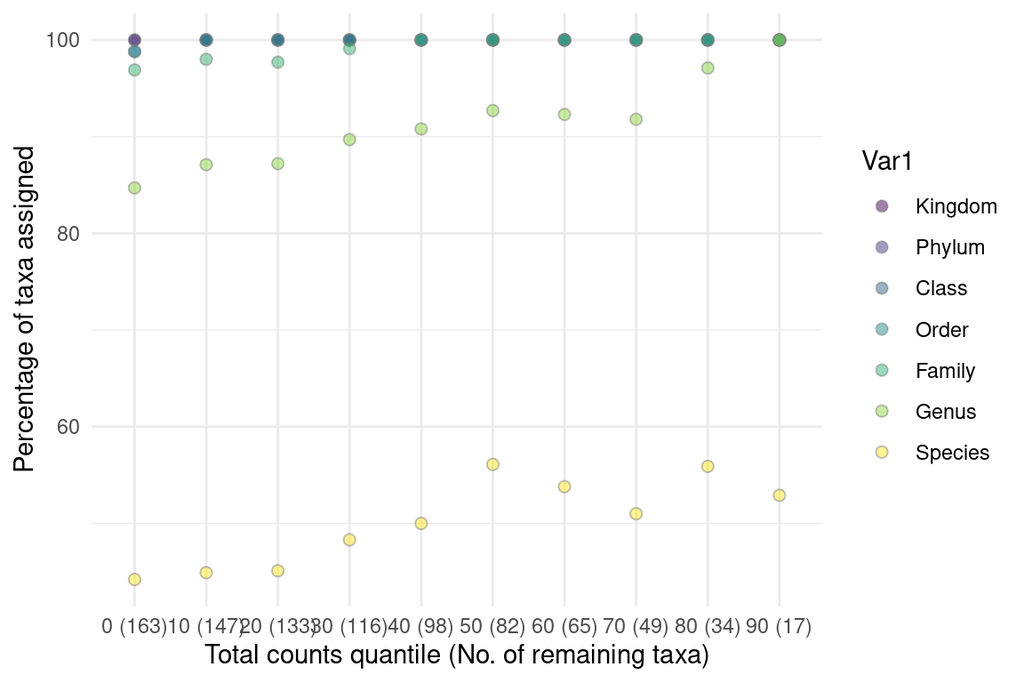

```r
p <- trendAbundanceAssignment(ps)
p + theme_minimal()
```